title: “Temperatura JP x CG” output: html_document: df_print: paged theme: sandstone —

```r
climas = read_csv(here::here("data/clima_cg_jp-semanal.csv"),
                  col_types = "cTdddddd")

cg = climas %>% filter(cidade == 'Campina Grande')

jp = climas %>% filter(cidade == 'João Pessoa')

glimpse(climas)
```

```
## Observations: 2,748
## Variables: 8
## $ cidade <chr> "Campina Grande", "Campina Grande", "Campina Grande", "Ca…
## $ semana <dttm> 1992-12-27, 1993-01-03, 1993-01-10, 1993-01-31, 1993-02-…
## $ tmedia <dbl> 26.13333, 26.11905, 25.76667, 25.74000, 26.31429, 26.2857…
## $ tmax   <dbl> 30.4, 32.4, 32.2, 32.0, 32.7, 32.7, 32.3, 32.3, 32.1, 31.…
## $ tmin   <dbl> 20.7, 19.3, 19.7, 19.9, 19.6, 20.0, 20.4, 21.2, 19.0, 19.…
## $ chuva  <dbl> 0.0, 0.0, 0.0, 0.4, 0.3, 0.0, 4.9, 0.0, 0.0, 6.1, 0.4, 1.…
## $ mes    <dbl> 12, 1, 1, 1, 2, 2, 2, 2, 10, 11, 11, 11, 11, 12, 12, 12, …
## $ ano    <dbl> 1992, 1993, 1993, 1993, 1993, 1993, 1993, 1993, 1993, 199…
```

## Temperatura

### Quais os meses mais quentes e mais frios?

Para fazer essa análise eu considerei a média da soma das temperaturas médias coletadas ao longo do mês. Além disso fiz essa análise considerando cada cidade indivudualmente e também juntando os dados das duas cidades.

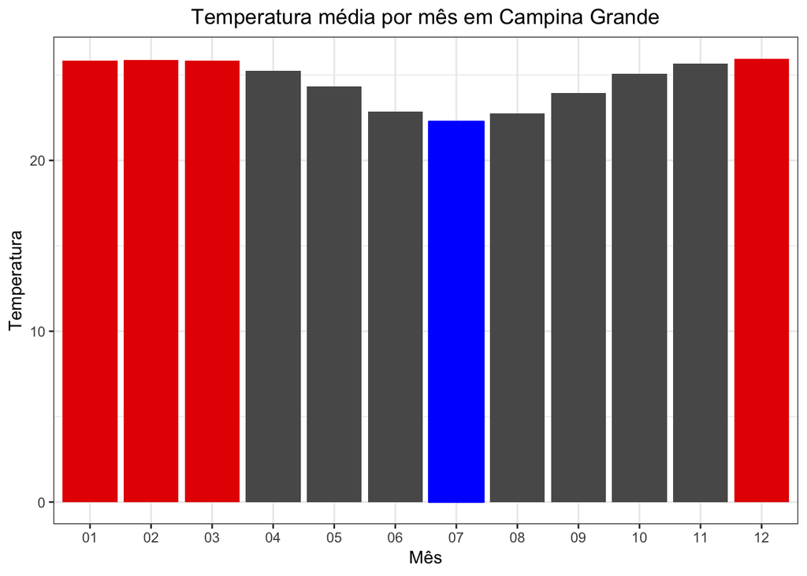

```r
cg_hot = cg %>% select(cidade, semana, tmedia) %>% mutate(month = format(semana, "%m"), year = format(semana, "%Y")) %>% group_by(month) %>% summarise(tmed = mean(tmedia))

ggplot(data=cg_hot, mapping=aes(x=month, y=tmed)) + ggtitle("Temperatura média por mês em Campina Grande") + theme(plot.title = element_text(hjust = 0.5)) + ylab('Temperatura') + xlab("Mês") + geom_col(data=cg_hot[7,], colour="blue", fill=rgb(0,0,1)) + geom_col(data=cg_hot[-c(1,2,3,7,12),]) + geom_col(data=cg_hot[-c(4,5,6,7,8,9,10,11),], fill=rgb(0.9,0,0))
```

[figure not shown]

```r
jp_hot = jp %>% select(cidade, semana, tmedia) %>% mutate(month = format(semana, "%m"), year = format(semana, "%Y")) %>% group_by(month) %>% summarise(tmed = mean(tmedia))

ggplot(data=jp_hot, mapping=aes(x=month, y=tmed)) + geom_col(data=cg_hot[7,], colour="blue", fill=rgb(0,0,1)) + ggtitle("Temperatura média por mês em João Pessoa") + theme(plot.title = element_text(hjust = 0.5)) + ylab('Temperatura') + xlab("Mês") + geom_col(data=jp_hot[-c(7),]) + geom_col(data=jp_hot[3,], colour="red", fill=rgb(0.9,0,0))
```

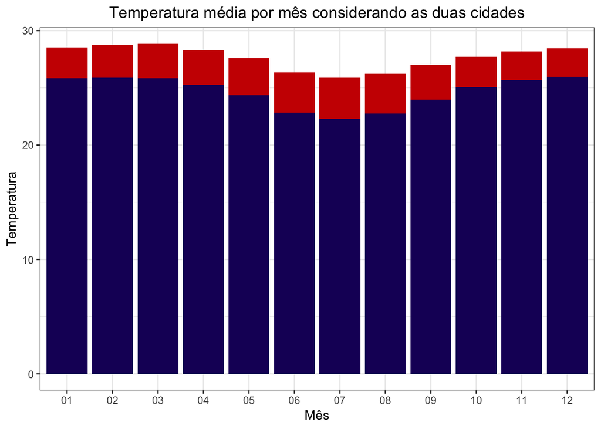

```r
ggplot(mapping=aes(x=month, y=tmed)) + geom_col(data=jp_hot, fill=rgb(0.8,0.1,0)) + geom_col(data=cg_hot, fill=rgb(0.1,0,0.4)) + ggtitle("Temperatura média por mês considerando as duas cidades") + theme(plot.title = element_text(hjust = 0.5)) + ylab('Temperatura') + xlab("Mês")
```

### Qual foi o São João mais frio de CG que está nos nossos dados?

Para essa análise eu considerei que o São João corresponde a todo o mês de Junho tendo em vista que o dia de São João é 24/06 e temos festa na cidade praticamente todos os dias desse mês.

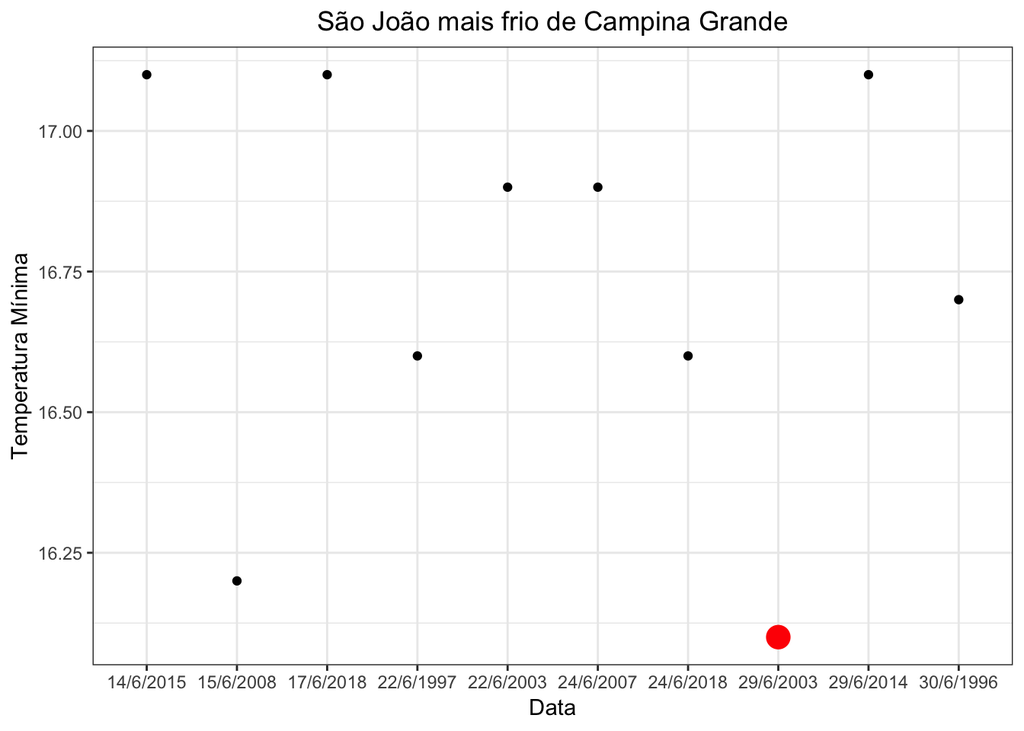

```r
top_10_menores_temperaturas = climas %>% select(cidade, semana, tmin) %>% filter(cidade == 'Campina Grande', month(semana) == 6) %>% arrange(desc(tmin)) %>% tail(campina_grande, n=10)

ggplot(data=top_10_menores_temperaturas, mapping = aes(x = paste(day(semana), month(semana), year(semana), sep="/"), y = tmin, )) + geom_point() + xlab("Data") + ylab("Temperatura Mínima") + ggtitle("São João mais frio de Campina Grande") + theme(plot.title = element_text(hjust = 0.5)) +  geom_point(data=top_10_menores_temperaturas[10, ], colour="red", size=5)
```

Portanto, nesse caso, o São João mais frio foi no dia 29/06/2003 com a temperatura mínima registrada de aproximadamente 16ºC

## Chuva

### Quanto chove por semana em JP e CG?

```r
chuvas_jp = climas %>% filter(cidade=="João Pessoa", chuva>10) %>% select(chuva, semana)
chuvas_cg = climas %>% filter(cidade=="Campina Grande", chuva>10) %>% select(chuva, semana)
```

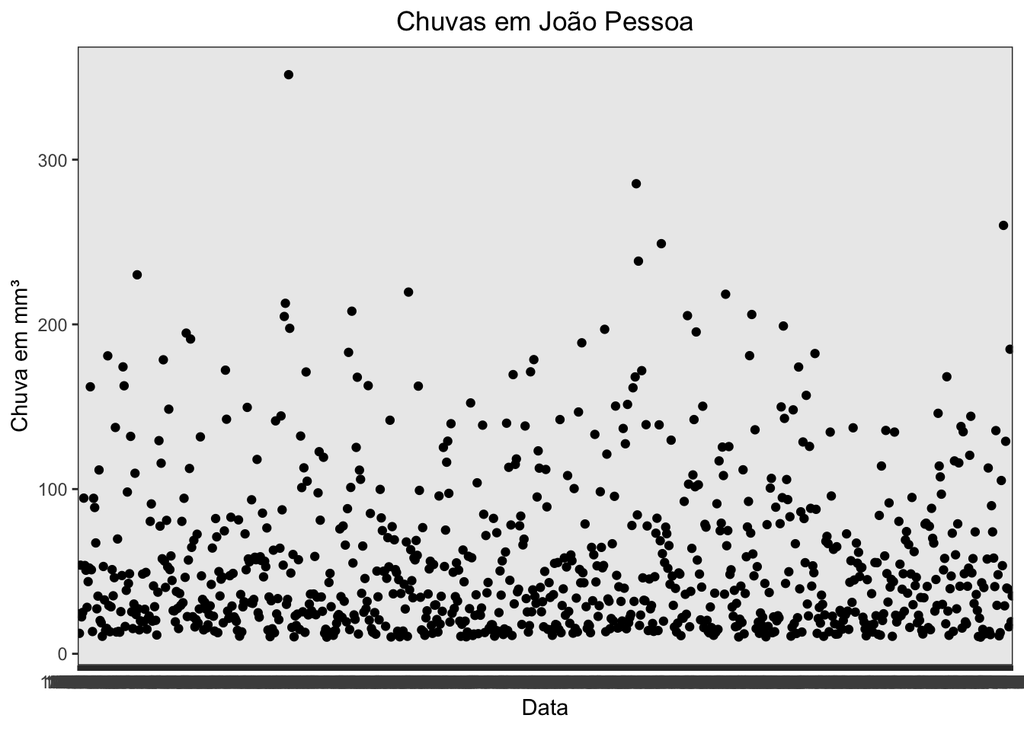

```r
ggplot(data=chuvas_jp, mapping = aes(x = paste(day(semana), month(semana), year(semana), sep="/"), y = chuva)) + xlab("Data") + ylab("Chuva em mm³") + ggtitle("Chuvas em João Pessoa") + theme(plot.title = element_text(hjust = 0.5)) + geom_point()
```

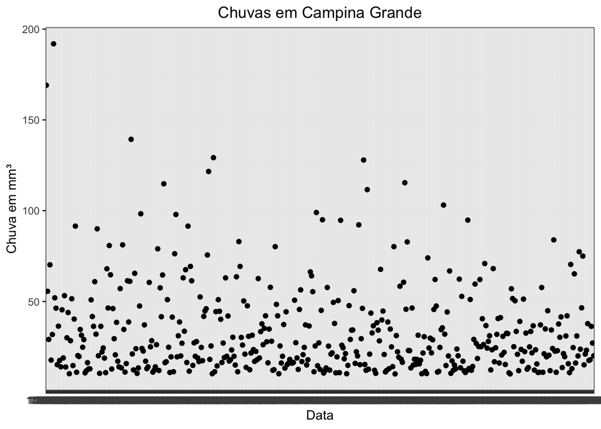

```r
ggplot(data=chuvas_cg, mapping = aes(x = paste(day(semana), month(semana), year(semana), sep="/"), y = chuva)) + xlab("Data") + ylab("Chuva em mm³") + ggtitle("Chuvas em Campina Grande") + theme(plot.title = element_text(hjust = 0.5)) + geom_point()
```

### No geral, onde chove mais?

Para responder essa pergunta eu basicamente criei dois gráficos de pontos “sobrepostos” com o volume de chuva por semana nas duas cidades. E podemos observar que em João Pessoa chove mais tanto com relação ao número de vezes quanto ao volume de água.

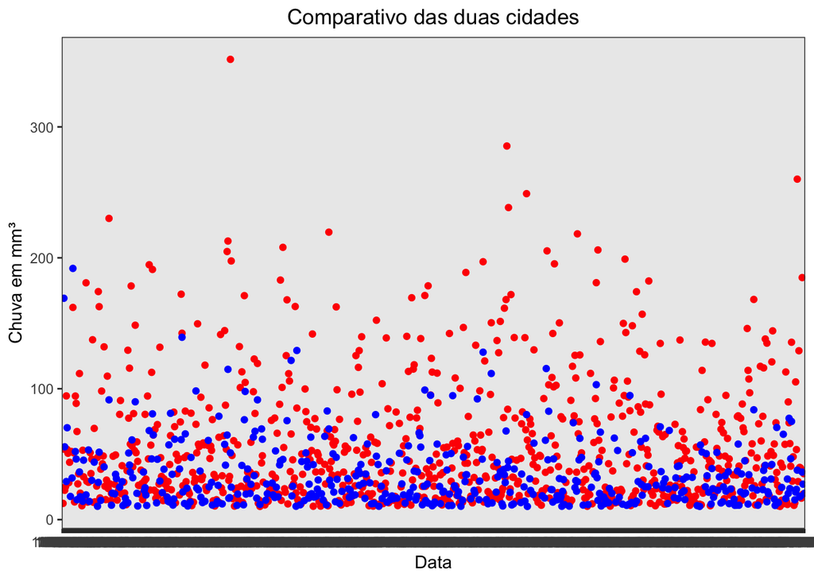

```r
ggplot(mapping = aes(x = paste(day(semana), month(semana), year(semana), sep="/"), y = chuva)) + xlab("Data") + ylab("Chuva em mm³") + ggtitle("Comparativo das duas cidades") + theme(plot.title = element_text(hjust = 0.5)) + geom_point(data=chuvas_jp, colour="red")+ geom_point(data=chuvas_cg, colour="blue")
```

Como podemos observar no gráfico acima em João Pessoa (representado em vermelho) chove muito mais, tanto em quantidade quanto em volume.

Agora vejamos a quantidade de chuvas por mês em cada cidade.

```r
chuvas_por_mes_jp = climas %>% filter(cidade=="João Pessoa", chuva>10) %>%  select(chuva, semana) %>% mutate(month = format(semana, "%m"), year = format(semana, "%Y")) %>% group_by(month) %>% summarise(cmed = mean(chuva))
chuvas_por_mes_cg = climas %>% filter(cidade=="Campina Grande", chuva>10) %>% select(chuva, semana) %>% mutate(month = format(semana, "%m"), year = format(semana, "%Y")) %>% group_by(month) %>% summarise(cmed = mean(chuva))
```

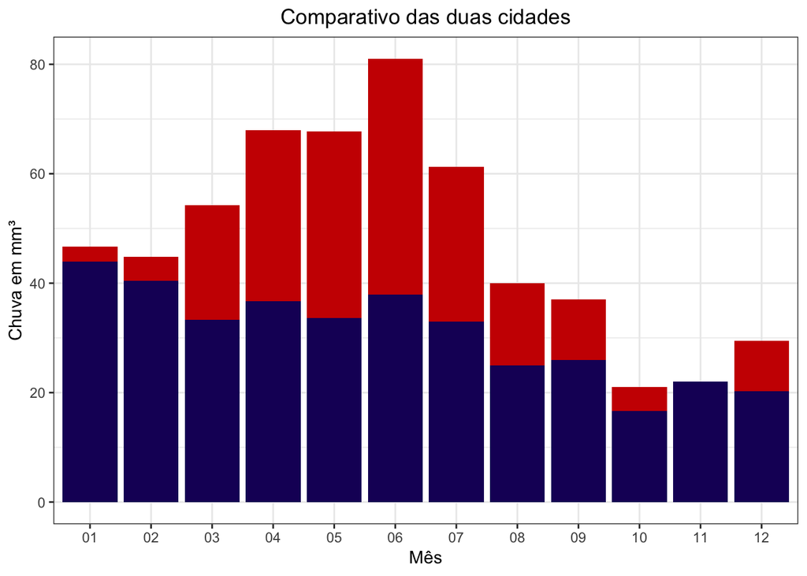

```r
ggplot(mapping = aes(x=month,y=cmed)) + geom_col(data=chuvas_por_mes_jp, fill=rgb(0.8,0.1,0)) + xlab("Mês")  + geom_col(data=chuvas_por_mes_cg, fill=rgb(0.1,0,0.4)) + ylab("Chuva em mm³") + ggtitle("Comparativo das duas cidades") + theme(plot.title = element_text(hjust = 0.5))
```

Como podemos observar no gráfico acima em João Pessoa (representado em vermelho) chove muito mais que em Campina Grande.